# Homework 10

Yu-Jen Lin

#### b04b01036@ntu.edu.tw

#### ——————————————————————————————————————————————————–

#### 1. Use the “dominant” copepod species data (from HW1) and environmental data (from HW3). Apply constrained ordination:

#### 1) determine an appropriate response model;

#### 2) select a set of independent variables;

#### 3) conduct ordination (RDA or CCA);

#### 4) interpret the results. Try different plotting methods; e.g., to display your cluster analysis results on the triplot and interpret how the groups vary with respect to environmental variables.

#### Retrieve the dominant species from HW1

```r
enviANDdensity <- read.csv("~/R/enviANDdensity.csv", row.names = 1, header=T)

dominant = read.csv("~/R/dominant.csv",row.names = 1,header=T) # examples HW1
data = t(dominant)
data = data/sum(data) # get the propotion data

y = data
x = enviANDdensity
```

# RDA

```r
library(vegan)
# normalize the dominant species data
y.log = log(y+1)    #log-transform y
y.chord = data.frame(matrix(0,nrow(y.log),ncol(y.log)))    #row normalization
rsum = apply(y.log,1,sum)
for(i in 1:nrow(y.log)){
  y.chord[i,] = y.log[i,]/rsum[i]
}
```

#### 1) determine an appropriate response model

```r
# Determine an appropriate species response model
y.dca = decorana(y.log)
y.dca
```

```
##
## Call:
## decorana(veg = y.log)
##
## Detrended correspondence analysis with 26 segments.
## Rescaling of axes with 4 iterations.
##
##                   DCA1   DCA2   DCA3    DCA4
## Eigenvalues     0.5511 0.2721 0.2263 0.13947
## Decorana values 0.5546 0.2866 0.1340 0.06851
## Axis lengths    3.9735 2.3410 1.7177 1.45514
```

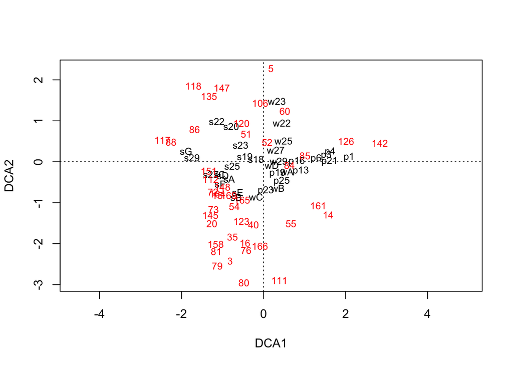

```r
plot(y.dca,type='text')
```

```r
## Axis length of DCA1 >4 : CCA
## Axis length of DCA1 3-4: CCA & RDA -> Here, I choose to use the RDA.
## Axis length of DCA1 <3 : RDA
```

#### 2) select a set of independent variables

```r
# Check multicollinearity in explanatory variables
## found that Temperature and maxT are highly correlated 0.98
round(as.dist(cor(x)),2)
```

```
##                           Depth Temperature Salinity Fluorescence
## Temperature                0.31
## Salinity                   0.39        0.60
## Fluorescence              -0.28        0.27     0.12
## DissolvedOxygen           -0.32       -0.99    -0.67        -0.26
## maxT                       0.28        0.98     0.54         0.27
## maxS                       0.45        0.51     0.87         0.15
## maxF                      -0.25        0.32     0.21         0.95
## MaxDO                      0.11       -0.82    -0.54        -0.34
## FishDensity..ind..1000m3. -0.14        0.50     0.34         0.24
## CopepodDensity.ind..m3.   -0.16        0.44     0.21         0.25
##                           DissolvedOxygen  maxT  maxS  maxF MaxDO
## Temperature
## Salinity
## Fluorescence
## DissolvedOxygen
## maxT                                -0.97
## maxS                                -0.57  0.52
## maxF                                -0.32  0.33  0.24
## MaxDO                                0.84 -0.80 -0.35 -0.36
## FishDensity..ind..1000m3.           -0.49  0.50  0.33  0.32 -0.49
## CopepodDensity.ind..m3.             -0.40  0.44  0.17  0.39 -0.45
##                           FishDensity..ind..1000m3.
## Temperature
## Salinity
## Fluorescence
## DissolvedOxygen
## maxT
## maxS
## maxF
## MaxDO
## FishDensity..ind..1000m3.
## CopepodDensity.ind..m3.                        0.65
```

```r
## Keep the variable with the larger constrained eigenvalue
rda(y.chord~Temperature,data=x)
```

```
## Call: rda(formula = y.chord ~ Temperature, data = x)
##
##               Inertia Proportion Rank
## Total         0.11538    1.00000
## Constrained   0.03416    0.29611    1
## Unconstrained 0.08121    0.70389   32
## Inertia is variance
##
## Eigenvalues for constrained axes:
##    RDA1
## 0.03416
##
## Eigenvalues for unconstrained axes:
##      PC1      PC2      PC3      PC4      PC5      PC6      PC7      PC8
## 0.022097 0.017499 0.011313 0.007898 0.005964 0.004039 0.002748 0.002575
## (Showed only 8 of all 32 unconstrained eigenvalues)
```

```r
rda(y.chord~maxT,data=x)
```

```
## Call: rda(formula = y.chord ~ maxT, data = x)
##
##               Inertia Proportion Rank
## Total         0.11538    1.00000
## Constrained   0.03447    0.29873    1
## Unconstrained 0.08091    0.70127   32
## Inertia is variance
##
## Eigenvalues for constrained axes:
##    RDA1
## 0.03447
##
## Eigenvalues for unconstrained axes:
##      PC1      PC2      PC3      PC4      PC5      PC6      PC7      PC8
## 0.022004 0.017966 0.011161 0.007932 0.005267 0.004040 0.002663 0.002542
## (Showed only 8 of all 32 unconstrained eigenvalues)
```

```r
## Variance inflation factors (VIF)
### Avoid selecting highly correlated independent variables (multicollinearity)
### When R^2 is large, it means that this x variable is not unique -> we dont want.
vif.cca(rda(y.chord~.,data=x))
```

```
##                     Depth               Temperature
##                  4.298115                332.962148
##                  Salinity              Fluorescence
##                 21.043279                 17.872218
##           DissolvedOxygen                      maxT
##                308.418334                 96.951691
##                      maxS                      maxF
##                 17.002940                 19.787383
##                     MaxDO FishDensity..ind..1000m3.
##                 16.095204                  2.410176
##   CopepodDensity.ind..m3.
##                  3.505421
```

```r
# Stepwise variable selection: forward # for RDA
y.full = rda(y.chord~.,data=x)
y.red = rda(y.chord~1,data=x)
y.rda = step(y.red,scope=list(lower=~1,upper=formula(y.full))) # step can also be used in regression
```

```
## Start:  AIC=-72.44
## y.chord ~ 1
##
##                             Df     AIC
## + maxT                       1 -82.505
## + Temperature                1 -82.378
## + DissolvedOxygen            1 -81.712
## + MaxDO                      1 -78.225
## + CopepodDensity.ind..m3.    1 -73.893
## + Salinity                   1 -73.639
## + FishDensity..ind..1000m3.  1 -73.622
## + Depth                      1 -73.359
## + maxS                       1 -73.285
## <none>                         -72.440
## + maxF                       1 -72.088
## + Fluorescence               1 -71.972
##
## Step:  AIC=-82.51
## y.chord ~ maxT
##
##                             Df     AIC
## + Depth                      1 -83.186
## + CopepodDensity.ind..m3.    1 -83.125
## + maxS                       1 -82.793
## + Salinity                   1 -82.669
## + maxF                       1 -82.560
## <none>                         -82.505
## + Fluorescence               1 -82.081
## + FishDensity..ind..1000m3.  1 -81.989
## + MaxDO                      1 -81.628
## + DissolvedOxygen            1 -81.558
## + Temperature                1 -81.184
## - maxT                       1 -72.440
##
## Step:  AIC=-83.19
## y.chord ~ maxT + Depth
##
##                             Df     AIC
## + CopepodDensity.ind..m3.    1 -83.949
## + maxS                       1 -83.483
```

[output cut: 29 more lines]

```
## y.chord ~ maxT + Depth + CopepodDensity.ind..m3. + maxS
##
##                             Df     AIC
## <none>                         -84.356
## + MaxDO                      1 -84.216
## + maxF                       1 -84.048
## - maxS                       1 -83.949
## + Fluorescence               1 -83.856
## - Depth                      1 -83.727
## + Salinity                   1 -83.619
## - CopepodDensity.ind..m3.    1 -83.483
## + DissolvedOxygen            1 -83.319
## + Temperature                1 -83.058
## + FishDensity..ind..1000m3.  1 -82.651
## - maxT                       1 -75.023
```

```r
y.rda$anova
```

```
##                        Step Df  Deviance Resid. Df Resid. Dev       AIC
## 1                           NA        NA        33   3.807435 -72.43976
## 2                    + maxT -1 1.1374021        32   2.670033 -82.50517
## 3                   + Depth -1 0.2024686        31   2.467564 -83.18639
## 4 + CopepodDensity.ind..m3. -1 0.1925493        30   2.275015 -83.94871
## 5                    + maxS -1 0.1555099        29   2.119505 -84.35605
```

```r
# Stepwise variable selection: backward
y.rda = step(y.full,scope=list(lower=formula(y.red),upper=formula(y.full)))
```

```
## Start:  AIC=-86.03
## y.chord ~ Depth + Temperature + Salinity + Fluorescence + DissolvedOxygen +
##     maxT + maxS + maxF + MaxDO + FishDensity..ind..1000m3. +
##     CopepodDensity.ind..m3.
##
##                             Df     AIC
## - FishDensity..ind..1000m3.  1 -87.558
## - maxT                       1 -87.354
## - maxS                       1 -86.992
## - MaxDO                      1 -86.655
## - Depth                      1 -86.427
## <none>                         -86.027
## - CopepodDensity.ind..m3.    1 -85.255
## - Fluorescence               1 -85.254
## - maxF                       1 -85.146
## - Temperature                1 -84.661
## - Salinity                   1 -84.067
## - DissolvedOxygen            1 -82.385
##
## Step:  AIC=-87.56
## y.chord ~ Depth + Temperature + Salinity + Fluorescence + DissolvedOxygen +
##     maxT + maxS + maxF + MaxDO + CopepodDensity.ind..m3.
##
##                             Df     AIC
## - maxT                       1 -88.957
## - maxS                       1 -88.589
## - MaxDO                      1 -88.161
## <none>                         -87.558
## - Depth                      1 -87.492
## - Fluorescence               1 -86.839
## - maxF                       1 -86.730
## - CopepodDensity.ind..m3.    1 -86.423
## - Temperature                1 -86.141
## + FishDensity..ind..1000m3.  1 -86.027
## - Salinity                   1 -85.755
## - DissolvedOxygen            1 -84.069
##
## Step:  AIC=-88.96
## y.chord ~ Depth + Temperature + Salinity + Fluorescence + DissolvedOxygen +
##     maxS + maxF + MaxDO + CopepodDensity.ind..m3.
```

[output cut: 35 more lines]

```
##     maxF + CopepodDensity.ind..m3.
##
##                             Df     AIC
## <none>                         -90.054
## + MaxDO                      1 -89.580
## - CopepodDensity.ind..m3.    1 -89.562
## + maxS                       1 -89.467
## - Fluorescence               1 -89.107
## + maxT                       1 -89.028
## - maxF                       1 -88.805
## + FishDensity..ind..1000m3.  1 -88.551
## - Depth                      1 -87.223
## - Temperature                1 -85.031
## - DissolvedOxygen            1 -84.613
## - Salinity                   1 -83.845
```

```r
y.rda
```

```
## Call: rda(formula = y.chord ~ Depth + Temperature + Salinity +
## Fluorescence + DissolvedOxygen + maxF + CopepodDensity.ind..m3.,
## data = x)
##
##               Inertia Proportion Rank
## Total         0.11538    1.00000
## Constrained   0.06985    0.60538    7
## Unconstrained 0.04553    0.39462   26
## Inertia is variance
##
## Eigenvalues for constrained axes:
##    RDA1    RDA2    RDA3    RDA4    RDA5    RDA6    RDA7
## 0.03737 0.01596 0.00684 0.00403 0.00297 0.00186 0.00082
##
## Eigenvalues for unconstrained axes:
##      PC1      PC2      PC3      PC4      PC5      PC6      PC7      PC8
## 0.012913 0.008563 0.007012 0.004354 0.002814 0.002305 0.001552 0.001258
## (Showed only 8 of all 26 unconstrained eigenvalues)
```

```r
# (if intersted)
# Finding the subset of environmental variables so that the Euclidean distances of environmental variable have the max correlation with community dissimilarities
summary(bioenv(y.chord,x,index='euclidean'))
```

```
## 2047 possible subsets (this may take time...)
```

```
##                                                                                                                                size
## DissolvedOxygen                                                                                                                   1
## maxT maxS                                                                                                                         2
## Temperature maxT maxS                                                                                                             3
## Temperature DissolvedOxygen maxT maxS                                                                                             4
## Temperature Salinity DissolvedOxygen maxT maxS                                                                                    5
## Temperature Salinity DissolvedOxygen maxT maxS MaxDO                                                                              6
## Temperature Salinity DissolvedOxygen maxT maxS MaxDO FishDensity..ind..1000m3.                                                    7
## Depth Temperature Salinity DissolvedOxygen maxT maxS MaxDO CopepodDensity.ind..m3.                                                8
## Depth Temperature Salinity DissolvedOxygen maxT maxS MaxDO FishDensity..ind..1000m3. CopepodDensity.ind..m3.                      9
## Depth Temperature Salinity DissolvedOxygen maxT maxS maxF MaxDO FishDensity..ind..1000m3. CopepodDensity.ind..m3.                10
## Depth Temperature Salinity Fluorescence DissolvedOxygen maxT maxS maxF MaxDO FishDensity..ind..1000m3. CopepodDensity.ind..m3.   11
##                                                                                                                                correlation
## DissolvedOxygen                                                                                                                     0.5713
## maxT maxS                                                                                                                           0.5906
## Temperature maxT maxS                                                                                                               0.5908
## Temperature DissolvedOxygen maxT maxS                                                                                               0.5908
## Temperature Salinity DissolvedOxygen maxT maxS                                                                                      0.5781
## Temperature Salinity DissolvedOxygen maxT maxS MaxDO                                                                                0.5616
## Temperature Salinity DissolvedOxygen maxT maxS MaxDO FishDensity..ind..1000m3.                                                      0.5313
## Depth Temperature Salinity DissolvedOxygen maxT maxS MaxDO CopepodDensity.ind..m3.                                                  0.5105
## Depth Temperature Salinity DissolvedOxygen maxT maxS MaxDO FishDensity..ind..1000m3. CopepodDensity.ind..m3.                        0.4863
## Depth Temperature Salinity DissolvedOxygen maxT maxS maxF MaxDO FishDensity..ind..1000m3. CopepodDensity.ind..m3.                   0.4454
## Depth Temperature Salinity Fluorescence DissolvedOxygen maxT maxS maxF MaxDO FishDensity..ind..1000m3. CopepodDensity.ind..m3.      0.3787
```

```r
# Suppose we select these environmental variables
x.new = x[,c(1,10,11)] # I choose three environmental variables with the lowest VIF.
```

#### 3) conduct ordination (RDA or CCA)

```r
# Constrained ordination
y.rda = rda(y.chord~.,data=x.new)
summary(y.rda)
```

```
##
## Call:
## rda(formula = y.chord ~ Depth + FishDensity..ind..1000m3. + CopepodDensity.ind..m3.,      data = x.new)
##
## Partitioning of variance:
##               Inertia Proportion
## Total         0.11538     1.0000
## Constrained   0.02551     0.2211
## Unconstrained 0.08986     0.7789
##
## Eigenvalues, and their contribution to the variance
##
## Importance of components:
##                          RDA1     RDA2     RDA3     PC1     PC2     PC3
## Eigenvalue            0.01804 0.006169 0.001304 0.03402 0.01799 0.01077
## Proportion Explained  0.15637 0.053466 0.011303 0.29482 0.15592 0.09334
## Cumulative Proportion 0.15637 0.209834 0.221137 0.51596 0.67189 0.76522
##                            PC4      PC5      PC6      PC7      PC8
## Eigenvalue            0.006277 0.005137 0.003891 0.002928 0.002256
## Proportion Explained  0.054407 0.044523 0.033721 0.025380 0.019552
## Cumulative Proportion 0.819627 0.864149 0.897871 0.923251 0.942803
##                            PC9     PC10      PC11      PC12     PC13
## Eigenvalue            0.001572 0.001007 0.0008828 0.0005727 0.000501
## Proportion Explained  0.013626 0.008724 0.0076516 0.0049634 0.004342
## Cumulative Proportion 0.956429 0.965153 0.9728043 0.9777677 0.982110
##                            PC14      PC15      PC16      PC17      PC18
## Eigenvalue            0.0003897 0.0003444 0.0002703 0.0002384 0.0001865
## Proportion Explained  0.0033780 0.0029851 0.0023431 0.0020659 0.0016163
## Cumulative Proportion 0.9854881 0.9884732 0.9908163 0.9928822 0.9944986
##                            PC19      PC20      PC21      PC22      PC23
## Eigenvalue            0.0001303 0.0001154 9.894e-05 0.0000916 6.756e-05
## Proportion Explained  0.0011295 0.0010002 8.576e-04 0.0007939 5.855e-04
## Cumulative Proportion 0.9956281 0.9966283 9.975e-01 0.9982798 9.989e-01
##                            PC24      PC25      PC26      PC27      PC28
## Eigenvalue            4.377e-05 0.0000307 2.203e-05 2.166e-05 8.717e-06
## Proportion Explained  3.793e-04 0.0002661 1.909e-04 1.878e-04 7.555e-05
## Cumulative Proportion 9.992e-01 0.9995108 9.997e-01 9.999e-01 1.000e+00
##                            PC29      PC30
## Eigenvalue            3.741e-06 2.974e-07
## Proportion Explained  3.242e-05 2.578e-06
```

[output cut: 132 more lines]

```
## row28  0.215002  0.121847 -0.0094442 -0.021180  0.243962  0.268540
## row29  0.148092  0.207699  0.0210474 -0.162465  0.241773  0.080601
## row30  0.356597 -0.022282 -0.0336398 -0.070067  0.092747  0.104042
## row31 -0.133871  0.520200  0.0807473 -0.026329  0.146084 -0.073147
## row32 -0.083256  0.459629  0.0737300 -0.092157  0.099690 -0.190035
## row33  0.020456  0.344405  0.0355446 -0.128143  0.029740 -0.057547
## row34 -0.011839  0.379083  0.0502497 -0.126112  0.177157 -0.012821
##
##
## Biplot scores for constraining variables
##
##                              RDA1    RDA2    RDA3 PC1 PC2 PC3
## Depth                     -0.5375  0.8301  0.1482   0   0   0
## FishDensity..ind..1000m3. -0.6798 -0.5111 -0.5260   0   0   0
## CopepodDensity.ind..m3.   -0.6738 -0.6783  0.2930   0   0   0
```

```r
# Total inertia = total sum of variance of species columns
sum(apply(y.chord,2,var))
```

```
## [1] 0.1153768
```

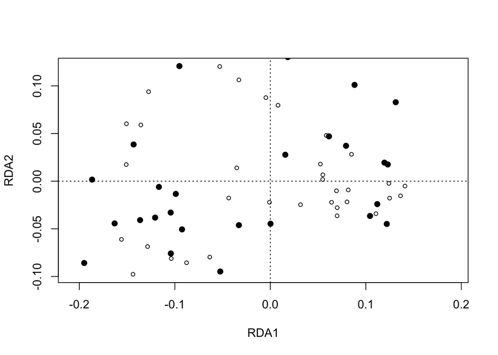

```r
# Compare differences in WA and LC sample scores
plot(y.rda,choices=c(1,2),type='points',display='lc',scaling=1) # either LC or WA or both
points(y.rda,choices=c(1,2),display='wa',pch=19,scaling=1)
```

```r
# Species and environment correlation for each axis
spenvcor(y.rda)
```

```
##      RDA1      RDA2      RDA3
## 0.7022701 0.6385652 0.4300862
```

```r
# IntER- and IntRA-set correlation (structure coefficients)
intersetcor(y.rda)
```

```
##                                 RDA1       RDA2        RDA3
## Depth                     -0.3774704  0.5301025  0.06372061
## FishDensity..ind..1000m3. -0.4773784 -0.3263732 -0.22623220
## CopepodDensity.ind..m3.   -0.4732241 -0.4331412  0.12600240
```

```r
intrasector = function(object){
  w = weights(object)
  lc = sweep(object$CCA$u,1,sqrt(w),"*")
  cor(qr.X(object$CCA$QR),lc)
}
intrasector(y.rda)
```

```
##                                 RDA1       RDA2       RDA3
## Depth                     -0.5375003  0.8301462  0.1481577
## FishDensity..ind..1000m3. -0.6797646 -0.5111040 -0.5260159
## CopepodDensity.ind..m3.   -0.6738490 -0.6783038  0.2929701
```

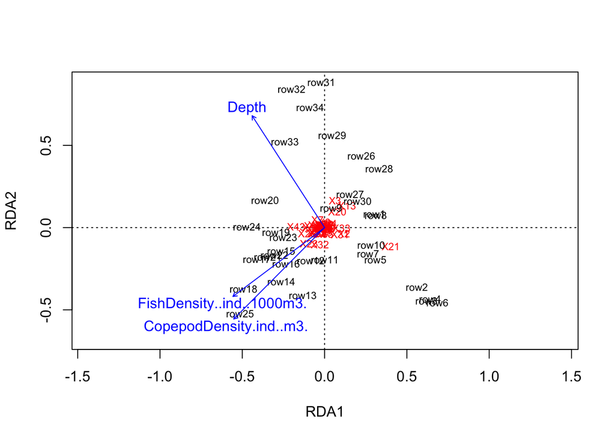

```r
# Triplot
plot(y.rda,choices=c(1,2),display=c('wa','sp','bp'),scaling=2)  #try scaling=1, 2, or 3
```

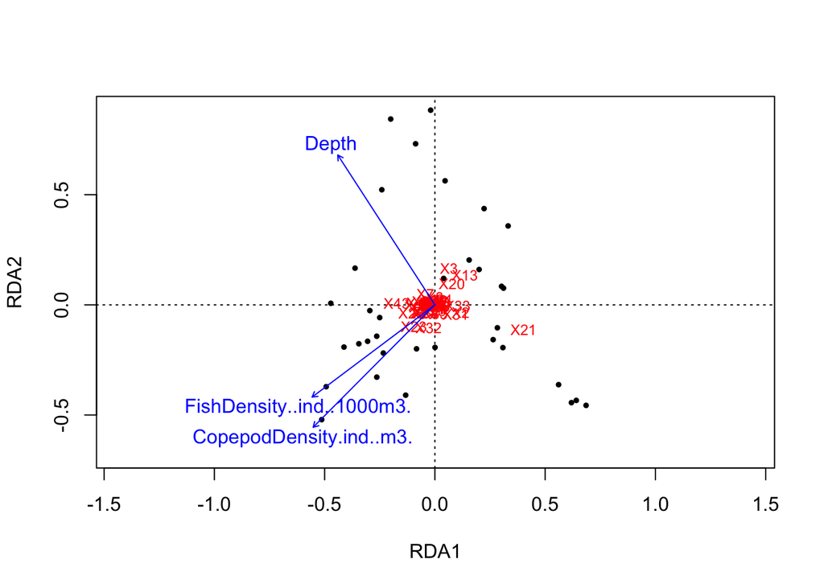

```r
plot(y.rda,choices=c(1,2),type='none',scaling=2)   #Use these lines to plot 1 item at a time
points(y.rda,choices=c(1,2),display='wa',pch=19,cex=.5,scaling=2)
text(y.rda,choices=c(1,2),display='sp',col='red',cex=.75,scaling=2)
text(y.rda,choices=c(1,2),display='bp',col='blue')
```

#### 4) interpret the results

#### row 1:10 -> spring

#### row 11:25 -> summer

#### row 26:34 -> winter

###### The results from cluster analysis is similar with RDA. In RDA plot, sites are separated according to species composition and environmental variables. Some sites are closer more than others because they have similar species composition or environmental conditions.

###### “Depth” can well distinguish the data from winter(row26-34) and spring(row1-10). “FishDensity” and “CopepodDensity” can well distinguish the data from summer(row11-25) and others.

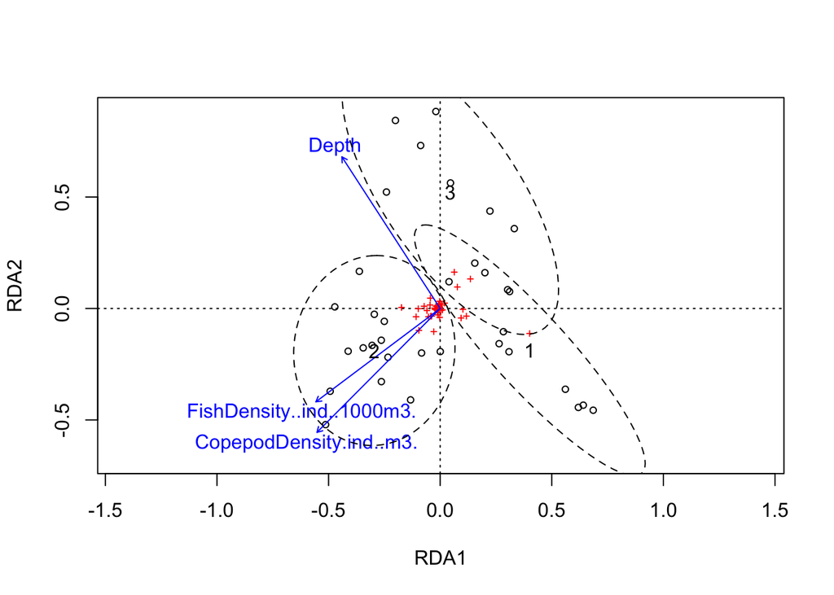

```r
# Extract the cluster analysis results I've done in previous homework
gp <- c(rep(1,10),rep(2,15),rep(3,9))

# Plot the cluster analysis results on the triplot
ordiplot(y.rda)
ordiellipse(y.rda, gp, conf = 0.95, lty = 2, label = T)
```

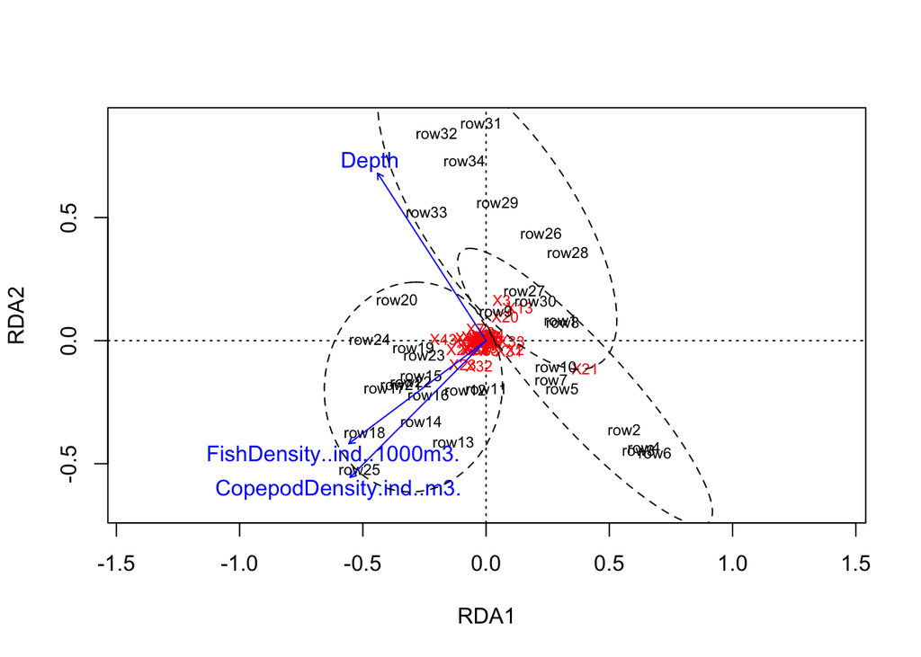

```r
ordiplot(y.rda, type = "text")
ordiellipse(y.rda, gp, conf = 0.95, lty = 2)
```

#### ——————————————————————————————————————————————————–

#### 2. Use the “dominant” copepod species data (from HW1) and environmental data (from HW3). Apply partial RDA (or CCA) to quantify how variance of species community is attributed to biological and physical habitat effects. In enviANDdensity.xls, columns B-J are physical variables, and columns K and L are biological variables.

```r
# Variance partitioning
y = data # dominant species
x = enviANDdensity
x.physical = x[,c(1:3)]
x.biological = x[,c(10:11)]

y.log = log(y+1) # log-transform y
y.chord = data.frame(matrix(0,nrow(y.log),ncol(y.log))) #row normalization # chord distance (species data)
rsum = apply(y.log,1,sum)
for(i in 1:nrow(y.log)){
    y.chord[i,] = y.log[i,]/rsum[i]
}

# RDA with plot variables after partialling out patch, landscape, and space effects (modify z matrix for partialling out other effects)
z = cbind(x.physical, x.biological)
z.plot = rda(y.chord,x,z) # z environment factor that we want to control ( if no 3rd part -> regular RDA) # this is partial RDA

summary(z.plot)
```

```
##
## Call:
## rda(X = y.chord, Y = x, Z = z)
##
## Partitioning of variance:
##               Inertia Proportion
## Total         0.11538     1.0000
## Conditioned   0.05194     0.4502
## Constrained   0.02292     0.1987
## Unconstrained 0.04051     0.3511
##
## Eigenvalues, and their contribution to the variance
## after removing the contribution of conditiniong variables
##
## Importance of components:
##                          RDA1    RDA2     RDA3     RDA4     RDA5      RDA6
## Eigenvalue            0.01173 0.00486 0.002896 0.001668 0.001438 0.0003364
## Proportion Explained  0.18485 0.07661 0.045662 0.026291 0.022663 0.0053027
## Cumulative Proportion 0.18485 0.26147 0.307128 0.333419 0.356082 0.3613851
##                           PC1      PC2      PC3      PC4      PC5      PC6
## Eigenvalue            0.01282 0.007495 0.005632 0.004109 0.002312 0.001823
## Proportion Explained  0.20206 0.118162 0.088787 0.064781 0.036453 0.028747
## Cumulative Proportion 0.56344 0.681604 0.770391 0.835171 0.871625 0.900372
##                            PC7      PC8       PC9      PC10      PC11
## Eigenvalue            0.001477 0.001134 0.0008352 0.0007248 0.0005329
## Proportion Explained  0.023288 0.017879 0.0131675 0.0114258 0.0084009
## Cumulative Proportion 0.923660 0.941539 0.9547061 0.9661319 0.9745327
##                            PC12     PC13      PC14      PC15     PC16
## Eigenvalue            0.0003993 0.000339 0.0002391 0.0001456 0.000127
## Proportion Explained  0.0062946 0.005345 0.0037696 0.0022957 0.002003
## Cumulative Proportion 0.9808274 0.986172 0.9899420 0.9922377 0.994241
##                            PC17      PC18      PC19      PC20      PC21
## Eigenvalue            9.771e-05 8.832e-05 0.0000751 4.569e-05 0.0000394
## Proportion Explained  1.540e-03 1.392e-03 0.0011840 7.203e-04 0.0006211
## Cumulative Proportion 9.958e-01 9.972e-01 0.9983574 9.991e-01 0.9996988
##                            PC22
## Eigenvalue            1.911e-05
## Proportion Explained  3.012e-04
## Cumulative Proportion 1.000e+00
##
```

[output cut: 133 more lines]

```
## con31  0.383110 -0.1825597 -0.03479  0.077964 -0.28170  0.171313
## con32  0.114839 -0.1270251 -0.15439 -0.000898  0.16758 -0.096779
## con33  0.010641 -0.0219461 -0.09179  0.068906  0.12154 -0.043761
## con34  0.306098 -0.0325394 -0.14089  0.116429 -0.16590  0.229892
##
##
## Biplot scores for constraining variables
##
##                      RDA1      RDA2      RDA3      RDA4      RDA5     RDA6
## Fluorescence     0.111730 0.2993088 -0.701530 -0.089993 -0.417731 -0.06924
## DissolvedOxygen -0.072163 0.0006005 -0.013212  0.002946 -0.003123  0.01416
## maxT             0.002011 0.0194896 -0.005891  0.141351  0.009799 -0.10950
## maxS             0.035609 0.1373877 -0.146421  0.408221  0.042191 -0.02898
## maxF             0.125731 0.5170146 -0.532472 -0.085611 -0.377674 -0.08773
## MaxDO           -0.178786 0.2098576 -0.115879 -0.002106  0.214747  0.02648
```

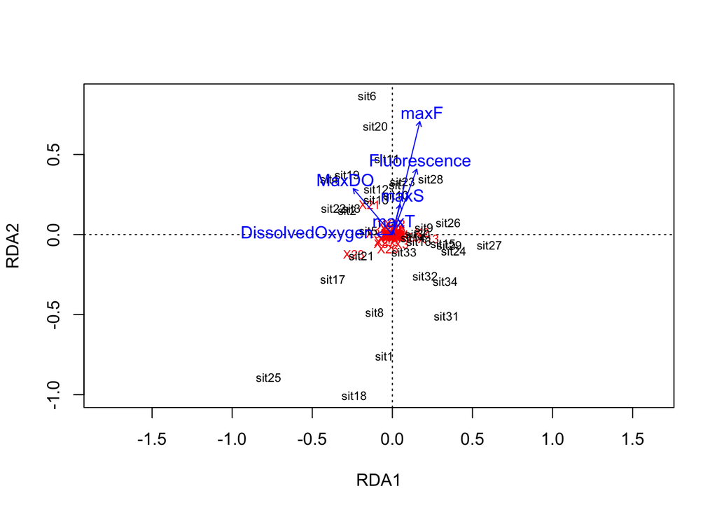

```r
plot(z.plot,choices=c(1,2),display=c('wa','sp','bp'),scaling=2)
```

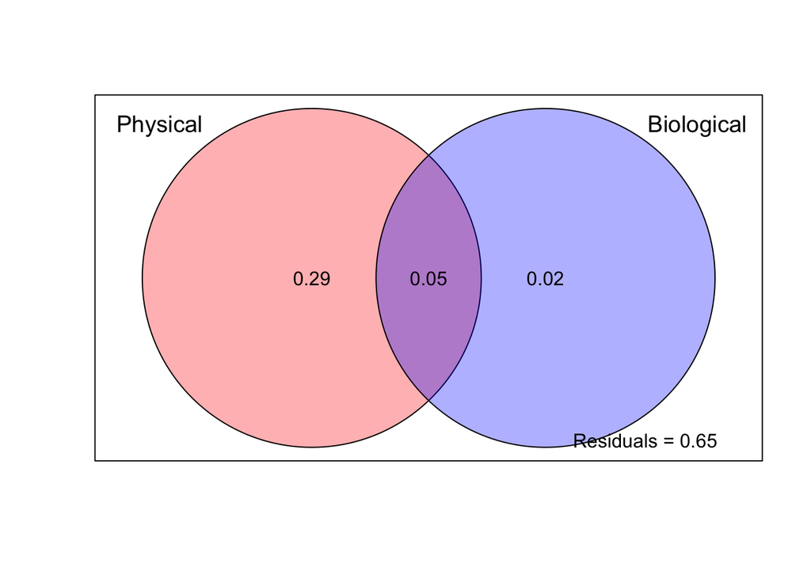

```r
# How variance of species community is attributed to biological and physical habitat effects.
rda <- rda(y.chord ~ ., data = x)
x.physical_rda <- rda(y.chord, x.physical, x.biological)
x.biological_rda <- rda(y.chord, x.biological, x.physical)
x.physical_r2 = x.physical_rda$CCA$tot.chi / x.physical_rda$tot.chi
x.biological_r2 = x.biological_rda$CCA$tot.chi / x.biological_rda$tot.chi
r2 = rda$CCA$tot.chi / rda$tot.chi - x.physical_r2 - x.biological_r2

vp = varpart(y.chord, x.physical, x.biological)
plot(vp, bg = c("red", "blue"), Xnames = c("Physical", "Biological"), alpha = 80)
```